# TCGA-KIRC Multi-Omics Prognostic Biomarker Analysis

Jialu Li

2025-12-02

```r
local({
  r <- getOption("repos")
  r["CRAN"] <- "https://cloud.r-project.org"
  options(repos = r)
})
if (!requireNamespace("data.table", quietly = TRUE)) install.packages("data.table")
if (!requireNamespace("R.utils", quietly = TRUE)) install.packages("R.utils")

library(data.table)
library(survival)
```

```r
# Hi-Seq Data
download.file("https://tcga-xena-hub.s3.us-east-1.amazonaws.com/download/TCGA.KIRC.sampleMap%2FHiSeqV2.gz", "HiSeqV2.gz")

# Methylation
download.file("https://tcga-xena-hub.s3.us-east-1.amazonaws.com/download/TCGA.KIRC.sampleMap%2FHumanMethylation450.gz", "HumanMethylation450.gz")

# Curated Survival Data
download.file(
  "https://tcga-xena-hub.s3.us-east-1.amazonaws.com/download/survival%2FKIRC_survival.txt",destfile = "KIRC_survival.txt"
)

# Clinical Matrix
download.file("https://tcga-xena-hub.s3.us-east-1.amazonaws.com/download/TCGA.KIRC.sampleMap%2FKIRC_clinicalMatrix", "KIRC_clinicalMatrix")
```

```r
library(R.utils)
# Only download & unpack if not yet present
if (!file.exists("HiSeqV2")) {
  download.file("https://tcga-xena-hub.s3.us-east-1.amazonaws.com/download/TCGA.KIRC.SampleMap%2FHiSeqV2.gz",
                destfile = "HiSeqV2.gz", mode = "wb")
  R.utils::gunzip("HiSeqV2.gz", remove = TRUE)
}

if (!file.exists("HumanMethylation450")) {
  download.file("https://tcga-xena-hub.s3.us-east-1.amazonaws.com/download/TCGA.KIRC.SampleMap%2FHumanMethylation450.gz",
                destfile = "HumanMethylation450.gz", mode = "wb")
  R.utils::gunzip("HumanMethylation450.gz", remove = TRUE)
}
```

Data loading and sample ID standardization

```r
# RNA-seq data
rna.data <- read.table("HiSeqV2", sep="\t", header=TRUE, row.names=1)
rna.data <- as.matrix(rna.data)
colnames(rna.data) <- gsub("\\.", "-", colnames(rna.data))
dim(rna.data)
```

```
## [1] 20530   606
```

```r
rna.data[1:3,1:3]
```

```
##           TCGA-BP-4162-01 TCGA-CJ-5677-11 TCGA-DV-5566-01
## ARHGEF10L         10.5030         10.8969         10.7612
## HIF3A              5.5283          6.4943          5.7842
## RNF17              3.8036          0.0000          0.0000
```

```r
# Survival data
surv.data <- read.table("KIRC_survival.txt", sep="\t", header=TRUE, row.names=1)
rownames(surv.data) <- gsub("\\.", "-", rownames(surv.data))
surv.data[1:3,]
```

```
##                    X_PATIENT OS OS.time DSS DSS.time DFI DFI.time PFI PFI.time
## TCGA-3Z-A93Z-01 TCGA-3Z-A93Z  0     385   0      385   0      385   0      385
## TCGA-6D-AA2E-01 TCGA-6D-AA2E  0     362   0      362  NA       NA   0      362
## TCGA-A3-3306-01 TCGA-A3-3306  0    1120   0     1120  NA       NA   0     1120
##                 Redaction
## TCGA-3Z-A93Z-01        NA
## TCGA-6D-AA2E-01        NA
## TCGA-A3-3306-01        NA
```

```r
# Clinical data
clin.data <- read.table("KIRC_clinicalMatrix", sep="\t", header=TRUE, row.names=1)
rownames(clin.data) <- gsub("\\.", "-", rownames(clin.data))
clin.data[1:3,]
```

[output not shown]

[output cut: 213 more lines]

[output not shown]

```r
# sample matching
common.samples <- intersect(colnames(rna.data), rownames(surv.data))

rna.data  <- rna.data[, common.samples]
surv.data <- surv.data[common.samples, ]
clin.data <- clin.data[common.samples, ]
```

Construction of survival analysis objects

```r
# Create survival object, look for associations with patient outcomes
os.time <- surv.data[colnames(rna.data), "OS.time"]
os.event <- as.numeric(surv.data[colnames(rna.data), "OS"])
kirc.os <- Surv(os.time, os.event)

# fit a single Cox Proportional Hazards regression model to look at survival in the cohort
coxph(kirc.os ~rna.data[1,])
```

```
## Call:
## coxph(formula = kirc.os ~ rna.data[1, ])
##
##                   coef exp(coef) se(coef)      z      p
## rna.data[1, ] -0.16369   0.84900  0.09755 -1.678 0.0933
##
## Likelihood ratio test=2.67  on 1 df, p=0.1022
## n= 606, number of events= 202
```

Batch univariate Cox regression (core screening step)

```r
# fit a univariate model for each genes's expression, and find those most significantly associated to patient outcome
n <- nrow(rna.data)
results.univariate <- data.frame(
  HR   = rep(NA_real_, n),
  LCI  = rep(NA_real_, n),
  UCI  = rep(NA_real_, n),
  PVAL = rep(NA_real_, n),
  row.names = rownames(rna.data)
)


for(i in 1:nrow(rna.data)) {
  coxphmodel <- coxph(kirc.os ~ as.numeric(rna.data[i,]))
  s <- summary(coxphmodel)
  results.univariate[i,] <- c(s$coef[1,2], s$conf.int[1,3:4], s$coef[1,5])
}
```

[output not shown]

[output cut: 35 more lines]

[output not shown]

```r
# Adjust p-values using FDR
results.univariate$FDR <- p.adjust(results.univariate$PVAL, method="fdr")

# Sort by significance
results.univariate <- results.univariate[order(results.univariate$FDR),]
head(results.univariate, 10)
```

```
##                  HR       LCI       UCI         PVAL          FDR
## OTX1      1.5569005 1.4200901 1.7068911 3.962887e-21 8.023658e-17
## COL7A1    1.3021668 1.2302992 1.3782326 7.855024e-20 6.536490e-16
## HHIPL2    1.5581229 1.4160096 1.7144989 1.004843e-19 6.536490e-16
## STX1A     1.7666535 1.5620368 1.9980737 1.291350e-19 6.536490e-16
## ZIC2      1.3106773 1.2336397 1.3925258 2.064750e-18 8.361001e-15
## ANKRD56   0.7370458 0.6879384 0.7896588 4.217070e-18 1.140084e-14
## MARS      3.2905080 2.5134205 4.3078518 4.504704e-18 1.140084e-14
## DONSON    2.2304647 1.8604178 2.6741159 4.429704e-18 1.140084e-14
## LOC286467 1.4542534 1.3356858 1.5833461 6.116367e-18 1.375979e-14
## UCN2      1.4731435 1.3488377 1.6089051 7.113485e-18 1.425996e-14
```

Clinical covariate screening

```r
# First find out which clinical data are associated with survival
clin.data<-clin.data[colnames(rna.data),]

# Age
sum(is.na(clin.data$age_at_initial_pathologic_diagnosis)) # 0
```

```
## [1] 0
```

```r
age <- as.numeric(clin.data$age_at_initial_pathologic_diagnosis)

# Gender
sum(is.na(clin.data$gender)) # 0
```

```
## [1] 0
```

```r
gender <- as.numeric(clin.data$gender == "MALE")

# Grade
# View the original distribution
unique_grades <- unique(clin.data$neoplasm_histologic_grade)
print(unique_grades) #"G2" "G4" "G3" "G1" "GX" ""
```

```
## [1] "G2" "G4" "G3" "G1" "GX" ""
```

```r
# Statistical problem data
problem_grade_count <- sum(clin.data$neoplasm_histologic_grade %in% c("GX", ""), na.rm = TRUE)
print(problem_grade_count) # 8
```

```
## [1] 8
```

```r
# Create a valid data mask
valid_grade_mask <- !clin.data$neoplasm_histologic_grade %in% c("GX", "")
# Filter valid data
valid_grade_data <- clin.data[valid_grade_mask, ]
valid_os_grade <- kirc.os[valid_grade_mask]
# Verify data alignment
stopifnot(length(valid_os_grade) == nrow(valid_grade_data))
# Grade grouping: G3 or G4 = high
grade.high <- rep(0, nrow(valid_grade_data))
grade.high[grep("G3|G4", valid_grade_data$neoplasm_histologic_grade)] <- 1

summary(coxph(valid_os_grade ~ grade.high))$coef
```

```
##                 coef exp(coef)  se(coef)        z     Pr(>|z|)
## grade.high 0.9607359  2.613619 0.1622019 5.923085 3.159581e-09
```

```r
# Stage
# View the original distribution
unique_stage <- unique(clin.data$pathologic_stage)
print(unique_stage) # "Stage I"       "Stage IV"      "Stage III"     "Stage II"      "[Discrepancy]"
```

```
## [1] "Stage I"       "Stage IV"      "Stage III"     "Stage II"
## [5] "[Discrepancy]"
```

```r
# Statistical problem data
problem_stage_count <- sum(clin.data$pathologic_stage == "[Discrepancy]", na.rm = TRUE)
print(problem_stage_count) # 2
```

```
## [1] 2
```

```r
# Create a valid data mask
valid_stage_mask <- !clin.data$pathologic_stage %in% "[Discrepancy]"
# Filter valid data
valid_stage_data <- clin.data[valid_stage_mask, ]
valid_os_stage <- kirc.os[valid_stage_mask]
# Verify data alignment
stopifnot(length(valid_os_stage) == nrow(valid_stage_data))
# Stage grouping: stage III or IV = high
stage.high <- rep(0, nrow(valid_stage_data))
stage.high[grep("Stage III|Stage IV", valid_stage_data$pathologic_stage)] <- 1

summary(coxph(valid_os_stage ~ stage.high))$coef
```

```
##                coef exp(coef)  se(coef)        z     Pr(>|z|)
## stage.high 1.330052  3.781242 0.1509783 8.809563 1.256348e-18
```

```r
# stage T grouping: T3 or T3a or T3b or T3c or T4 = high
unique_stage_T <- unique(clin.data$pathologic_T)
print(unique_stage_T) #  "T1b" "T3a" "T1a" "T2"  "T3b" "T4"  "T1"  "T2a" "T3"  "T3c" "T2b"
```

```
##  [1] "T1b" "T3a" "T1a" "T2"  "T3b" "T4"  "T1"  "T2a" "T3"  "T3c" "T2b"
```

```r
stage.T.high <- rep(0, nrow(clin.data))
stage.T.high[grep("T3|T3a|T3b|T3c|T4", clin.data$pathologic_T)] <- 1

# stage M
# View the original distribution
unique_stage_M <- unique(clin.data$pathologic_M)
print(unique_stage_M) #  "M0" "M1" "MX" ""
```

```
## [1] "M0" "M1" "MX" ""
```

```r
# Statistical problem data
problem_stage_M_count <- sum(clin.data$pathologic_M %in% c("MX", ""), na.rm = TRUE)
print(problem_stage_M_count) # 33
```

```
## [1] 33
```

```r
# Create a valid data mask
valid_M_mask <- !clin.data$pathologic_M %in% c("MX", "")
# Filter valid data
valid_M_data <- clin.data[valid_M_mask, ]
valid_os_M <- kirc.os[valid_M_mask]
# Verify data alignment
stopifnot(length(valid_os_M) == nrow(valid_M_data))
# stage M: M1 = high
stage.M.high <- rep(0, nrow(valid_M_data))
stage.M.high[grep("M1", valid_M_data$pathologic_M)] <- 1

summary(coxph(valid_os_M ~ stage.M.high))$coef
```

```
##                  coef exp(coef)  se(coef)        z    Pr(>|z|)
## stage.M.high 1.505058  4.504417 0.1455732 10.33884 4.70179e-25
```

```r
# stage N: Due to 52% of the N staging data being missing, this variable was not included in the final model
unique_stage_N <- unique(clin.data$pathologic_N)
print(unique_stage_N) # "N0" "NX" "N1"
```

```
## [1] "N0" "NX" "N1"
```

```r
problem_stage_N_count <- sum(clin.data$pathologic_N == "NX", na.rm = TRUE)
print(problem_stage_N_count) # 310
```

```
## [1] 310
```

```r
# Test associations
summary(coxph(kirc.os ~ age))$coef
```

```
##           coef exp(coef)    se(coef)        z     Pr(>|z|)
## age 0.03147105  1.031972 0.005932601 5.304765 1.128184e-07
```

```r
summary(coxph(kirc.os ~ gender))$coef
```

```
##              coef exp(coef)  se(coef)          z  Pr(>|z|)
## gender -0.0663466 0.9358065 0.1469742 -0.4514165 0.6516894
```

```r
summary(coxph(valid_os_grade ~ grade.high))$coef
```

```
##                 coef exp(coef)  se(coef)        z     Pr(>|z|)
## grade.high 0.9607359  2.613619 0.1622019 5.923085 3.159581e-09
```

```r
summary(coxph(valid_os_stage ~ stage.high))$coef
```

```
##                coef exp(coef)  se(coef)        z     Pr(>|z|)
## stage.high 1.330052  3.781242 0.1509783 8.809563 1.256348e-18
```

```r
summary(coxph(kirc.os ~ stage.T.high))$coef
```

```
##                  coef exp(coef)  se(coef)        z     Pr(>|z|)
## stage.T.high 1.095047  2.989323 0.1434497 7.633665 2.281725e-14
```

```r
summary(coxph(valid_os_M ~ stage.M.high))$coef
```

```
##                  coef exp(coef)  se(coef)        z    Pr(>|z|)
## stage.M.high 1.505058  4.504417 0.1455732 10.33884 4.70179e-25
```

Highly significant predictors (all p<0.001): Age (HR=1.03), Grade.high (HR=2.61), Stage.high (HR=3.78), Stage.T.high (HR=2.99), Stage.M.high (HR=4.50, strongest effect) Not associated: Gender (HR=0.94, p=0.65)

Univariate Cox results for clinical variables(forest map)

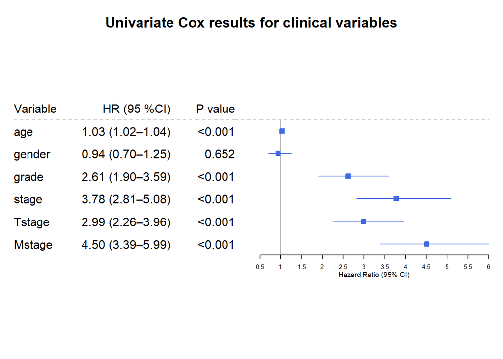

```r
library(forestplot)
# Fit a univariate Cox proportional hazards model to multiple clinical variables separately
vars.df <- list(
  age     = coxph(kirc.os ~ age),
  gender  = coxph(kirc.os ~ gender),
  grade   = coxph(valid_os_grade ~ grade.high),
  stage   = coxph(valid_os_stage ~ stage.high),
  Tstage  = coxph(kirc.os ~ stage.T.high),
  Mstage  = coxph(valid_os_M ~ stage.M.high)
)

# Extract Cox model results
res <- lapply(vars.df, function(fit) {
  s  <- summary(fit)$coef[1, ]
  HR <- s["exp(coef)"]
  se <- s["se(coef)"]
  z  <- qnorm(0.975)
  lower <- exp(log(HR) - z * se)
  upper <- exp(log(HR) + z * se)
  c(HR = HR, lower = lower, upper = upper, p = s["Pr(>|z|)"])
})

res <- as.data.frame(do.call(rbind, res))

# Text table of forest map
text_table <- cbind(c("Variable", rownames(res)),
                    c("HR (95 %CI)", sprintf("%.2f (%.2f–%.2f)",
                                             res$HR, res$lower, res$upper)),
                    c("P value", ifelse(res$p<0.001, "<0.001",
                                        sprintf("%.3f", res$p))))

# Draw a forest map
forestplot(text_table,
           mean = c(NA, res$HR),
           lower = c(NA, res$lower),
           upper = c(NA, res$upper),
           zero = 1,
           boxsize = 0.2,
           lineheight = unit(8, "mm"),
           hrzl_lines = list("2" = gpar(lty = 2, col = "gray")),
           col = fpColors(box = "royalblue", lines = "royalblue", zero = "gray"),
           title = "Univariate Cox results for clinical variables",
           xlab = "Hazard Ratio (95% CI)")
```

Multivariate Cox regression: fit a multivariate model using these covariates for each genes’s expression, and find those most significantly associated to patient outcome

```r
# sample matching
complete.samples <- intersect(
  intersect(rownames(valid_grade_data), rownames(valid_stage_data)),
  rownames(valid_M_data)
)

complete.rna.data  <- rna.data[, complete.samples]
complete.surv.data <- surv.data[complete.samples, ]
complete.clin.data <- clin.data[complete.samples, ]

# Create survival object
complete.os.time <- surv.data[colnames(complete.rna.data), "OS.time"]
complete.os.event <- as.numeric(surv.data[colnames(complete.rna.data), "OS"])
complete.kirc.os <- Surv(complete.os.time, complete.os.event)

# Align clinical and expression data
complete.clin.data <- clin.data[colnames(complete.rna.data),]

# Validate the concordance of column names in gene expression data with row names in survival and clinical data
all(rownames(complete.clin.data) == rownames(complete.surv.data) & rownames(complete.clin.data) == colnames(complete.rna.data))
```

```
## [1] TRUE
```

```r
# "Verify that the column names of the gene expression data are in the same order as the row names of the survival data and clinical data."

# Clinical covariates
complete.age <- as.numeric(complete.clin.data$age_at_initial_pathologic_diagnosis)
complete.grade.high <- rep(0, nrow(complete.clin.data))
complete.grade.high[grep("G3|G4", complete.clin.data$neoplasm_histologic_grade)] <- 1
complete.stage.high <- rep(0, nrow(complete.clin.data))
complete.stage.high[grep("Stage III|Stage IV", complete.clin.data$pathologic_stage)] <- 1
complete.stage.T.high <- rep(0, nrow(complete.clin.data))
complete.stage.T.high[grep("T3|T3a|T3b|T3c|T4", complete.clin.data$pathologic_T)] <- 1
complete.stage.M.high <- rep(0, nrow(complete.clin.data))
complete.stage.M.high[grep("M1", complete.clin.data$pathologic_M)] <- 1

# multivariate Cox regression
n <- nrow(complete.rna.data)
results.multivariate <- data.frame(
  HR   = rep(NA_real_, n),
  LCI  = rep(NA_real_, n),
  UCI  = rep(NA_real_, n),
  PVAL = rep(NA_real_, n),
  row.names = rownames(complete.rna.data)
)

for(i in 1:nrow(complete.rna.data)) {
  coxphmodel <- coxph(complete.kirc.os ~ complete.rna.data[i,] + complete.age + complete.grade.high + complete.stage.high + complete.stage.T.high + complete.stage.M.high)
  s <- summary(coxphmodel)
  results.multivariate[i,] <- c(s$coef[1,2], s$conf.int[1,3:4], s$coef[1,5])
}
```

[output not shown]

[output cut: 19 more lines]

[output not shown]

```r
results.multivariate$FDR <- p.adjust(results.multivariate$PVAL, method="fdr")
results.multivariate <- results.multivariate[order(results.multivariate$FDR),]
head(results.multivariate, 10)
```

```
##                HR       LCI       UCI         PVAL          FDR
## CDC7    1.9302056 1.6277286 2.2888912 3.960300e-14 8.016440e-10
## STX1A   1.5838369 1.4029071 1.7881008 1.085757e-13 1.098895e-09
## GBA3    0.8268163 0.7852448 0.8705887 5.000236e-13 2.653094e-09
## SLC3A1  0.7819939 0.7314883 0.8359866 5.242751e-13 2.653094e-09
## SEC61A2 2.2339172 1.7900991 2.7877709 1.138957e-12 4.610953e-09
## TMEM27  0.8165185 0.7717270 0.8639097 1.896056e-12 6.396660e-09
## DVL3    3.2644365 2.3437830 4.5467287 2.583879e-12 7.471840e-09
## COPS7B  3.1189869 2.2630732 4.2986145 3.651023e-12 9.238002e-09
## CORO6   1.3431283 1.2350191 1.4607010 5.570982e-12 1.252976e-08
## MARS    2.8312895 2.1019239 3.8137442 7.502816e-12 1.518720e-08
```

Perform univariate Cox regression for each gene using the same cohort of multivariate models.

```r
results.univariate <- data.frame(
  HR   = rep(NA_real_, n),
  LCI  = rep(NA_real_, n),
  UCI  = rep(NA_real_, n),
  PVAL = rep(NA_real_, n),
  row.names = rownames(complete.rna.data)
)

for(i in 1:nrow(complete.rna.data)) {
  coxphmodel <- coxph(complete.kirc.os ~ as.numeric(complete.rna.data[i,]))
  s <- summary(coxphmodel)
  results.univariate[i,] <- c(s$coef[1,2], s$conf.int[1,3:4], s$coef[1,5])
}
```

[output not shown]

[output cut: 31 more lines]

[output not shown]

```r
results.univariate$FDR <- p.adjust(results.univariate$PVAL, method="fdr")
results.univariate <- results.univariate[order(results.univariate$FDR),]
head(results.univariate, 10)
```

```
##                 HR      LCI      UCI         PVAL          FDR
## OTX1      1.602884 1.457165 1.763176 2.956325e-22 5.984192e-18
## STX1A     1.795660 1.589206 2.028935 5.802791e-21 5.873005e-17
## COL7A1    1.315751 1.241908 1.393985 1.259045e-20 6.371399e-17
## MARS      3.758486 2.845199 4.964933 1.144242e-20 6.371399e-17
## ANAPC7    6.458759 4.318207 9.660393 1.070782e-19 3.682827e-16
## LOC286467 1.493396 1.369544 1.628448 1.091639e-19 3.682827e-16
## UBE2S     1.983727 1.706492 2.306002 4.737545e-19 1.369963e-15
## ZIC2      1.316722 1.239101 1.399207 6.958984e-19 1.760797e-15
## HHIPL2    1.546407 1.403818 1.703478 1.025999e-18 2.076828e-15
## DONSON    2.316233 1.922778 2.790200 9.343352e-19 2.076828e-15
```

```r
summary(rna.data["GBA3",])
```

```
##    Min. 1st Qu.  Median    Mean 3rd Qu.    Max.
##   0.000   9.018  10.456   9.719  11.247  12.931
```

```r
results.univariate["GBA3",]
```

```
##             HR       LCI       UCI         PVAL         FDR
## GBA3 0.8386183 0.8005408 0.8785069 1.141246e-13 1.95772e-11
```

```r
results.multivariate["GBA3",]
```

```
##             HR       LCI       UCI         PVAL          FDR
## GBA3 0.8268163 0.7852448 0.8705887 5.000236e-13 2.653094e-09
```

Kaplan–Meier and Multivariate Cox Analyses of GBA3 Expression and Survival

```r
# Create binary GBA3-high (1) vs GBA3-low (0) based on median expression
GBA3.high <- as.numeric(complete.rna.data["GBA3",] > median(complete.rna.data["GBA3",]))
table(GBA3.high)
```

```
## GBA3.high
##   0   1
## 283 282
```

```r
# Multivariate Cox model
cox_model_GBA3.high <- coxph(complete.kirc.os ~ GBA3.high + complete.age + complete.grade.high + complete.stage.high + complete.stage.T.high + complete.stage.M.high)
summary(cox_model_GBA3.high)
```

```
## Call:
## coxph(formula = complete.kirc.os ~ GBA3.high + complete.age +
##     complete.grade.high + complete.stage.high + complete.stage.T.high +
##     complete.stage.M.high)
##
##   n= 565, number of events= 197
##
##                            coef exp(coef)  se(coef)      z Pr(>|z|)
## GBA3.high             -0.718777  0.487348  0.153748 -4.675 2.94e-06 ***
## complete.age           0.034512  1.035114  0.006623  5.211 1.88e-07 ***
## complete.grade.high    0.450204  1.568633  0.172364  2.612   0.0090 **
## complete.stage.high    0.674905  1.963847  0.331713  2.035   0.0419 *
## complete.stage.T.high -0.063687  0.938299  0.277807 -0.229   0.8187
## complete.stage.M.high  0.964862  2.624425  0.183626  5.255 1.48e-07 ***
## ---
## Signif. codes:  0 '***' 0.001 '**' 0.01 '*' 0.05 '.' 0.1 ' ' 1
##
##                       exp(coef) exp(-coef) lower .95 upper .95
## GBA3.high                0.4873     2.0519    0.3606    0.6587
## complete.age             1.0351     0.9661    1.0218    1.0486
## complete.grade.high      1.5686     0.6375    1.1189    2.1991
## complete.stage.high      1.9638     0.5092    1.0251    3.7624
## complete.stage.T.high    0.9383     1.0658    0.5443    1.6174
## complete.stage.M.high    2.6244     0.3810    1.8312    3.7613
##
## Concordance= 0.777  (se = 0.016 )
## Likelihood ratio test= 170  on 6 df,   p=<2e-16
## Wald test            = 168.4  on 6 df,   p=<2e-16
## Score (logrank) test = 198.3  on 6 df,   p=<2e-16
```

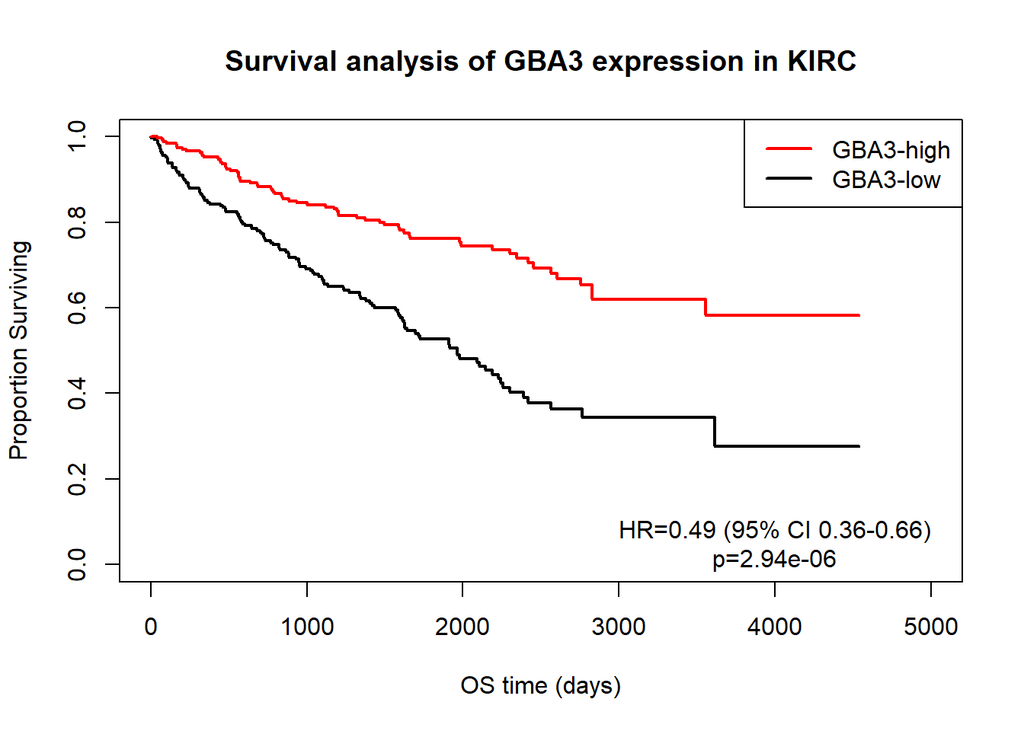

```r
# Visualize the Kaplan-Meier Plot for GBA3
plot(
  survfit(complete.kirc.os ~ GBA3.high),
  col=c("black", "red"),
  lwd=2,
  xlab="OS time (days)", ylab="Proportion Surviving",
  main="Survival analysis of GBA3 expression in KIRC",
  xlim = c(0, 5000)
)
legend("topright", legend=c("GBA3-high", "GBA3-low"), col=c("red", "black"), lwd=2)
text(4000, 0.05, "HR=0.49 (95% CI 0.36-0.66)
p=2.94e-06")
```

Let’s explore GBA3 expression differences explained by methylation

```r
if (!requireNamespace("BiocManager", quietly = TRUE))
    install.packages("BiocManager")

# Install chip annotation package+minfi
BiocManager::install(c("minfi", "IlluminaHumanMethylation450kanno.ilmn12.hg19"))
# Download from minifi
library(IlluminaHumanMethylation450kanno.ilmn12.hg19)
```

```
## locfit 1.5-9.12   2025-03-05
```

```
## Setting options('download.file.method.GEOquery'='auto')
```

```
## Setting options('GEOquery.inmemory.gpl'=FALSE)
```

```r
library(minfi)

# Extract the annotation data frame
meth.annot <- getAnnotation(IlluminaHumanMethylation450kanno.ilmn12.hg19)
head(meth.annot)
```

[output not shown]

[output cut: 18 more lines]

[output not shown]

Load methylation matrix

```r
meth.data <- read.table("HumanMethylation450", sep = "\t", header = TRUE, row.names = 1)
colnames(meth.data) <- gsub("\\.", "-", colnames(meth.data))

# Align samples with RNA
rna.data2  <- complete.rna.data[, colnames(complete.rna.data) %in% colnames(meth.data)]
meth.data2 <- meth.data[, colnames(meth.data) %in% colnames(rna.data2)]
surv.data2 <- complete.surv.data[colnames(rna.data2), ]

# Order consistently
rna.data2  <- rna.data2[,  order(colnames(rna.data2))]
meth.data2 <- meth.data2[, order(colnames(meth.data2))]
surv.data2 <- surv.data2[colnames(rna.data2), ]

# Force methylation to numeric matrix
meth.data2 <- as.matrix(meth.data2)
storage.mode(meth.data2) <- "numeric"
```

```r
rna.data2[1:3,1:4]
```

```
##           TCGA-3Z-A93Z-01 TCGA-A3-3357-01 TCGA-A3-3358-01 TCGA-A3-3367-01
## ARHGEF10L         10.2510         11.0201         10.5026         10.9486
## HIF3A              6.3672          6.2366          6.2248          8.7442
## RNF17              0.0000          0.0000          0.7103          1.3411
```

```r
meth.data2[1:3,1:4]
```

```
##            TCGA-3Z-A93Z-01 TCGA-A3-3357-01 TCGA-A3-3358-01 TCGA-A3-3367-01
## cg13332474          0.0300          0.0483          0.0292          0.0495
## cg00651829          0.0160          0.0229          0.0203          0.0170
## cg17027195          0.0641          0.0488          0.0361          0.0423
```

Get probes for GBA3

```r
# Extract probes for GBA3 from methylation annotation file 'meth.annot'
GBA3.probes  <- rownames(meth.annot)[grepl("\\bGBA3\\b",  meth.annot$UCSC_RefGene_Name)]

# Subset methylation to those probes
meth.data.GBA3 <- meth.data2[GBA3.probes, , drop = FALSE]
```

Filter probes with >50% missing values

```r
na.count <- apply(meth.data.GBA3, 1, function(x) sum(is.na(x))) # Calculate the number of missing values for each row
meth.data.GBA3 <- meth.data.GBA3[na.count <= 0.5 * ncol(meth.data.GBA3), , drop = FALSE] # Filter out rows with missing values not exceeding half of the total number of columns(samples)

nrow(meth.data.GBA3)
```

```
## [1] 3
```

Correlation between GBA3 expression and DNA methylation

```r
# Prepare result container
results <- matrix(NA_real_, nrow = nrow(meth.data.GBA3), ncol = 4)
rownames(results) <- rownames(meth.data.GBA3)
colnames(results) <- c("Cor.GBA3", "P.GBA3", # Correlation coefficient and p-value between methylation of the probe and GBA3 expression
                       "MedianMeth.High", "MedianMeth.Low") # Median methylation level of GBA3 high/low expression group

# GBA3 high/low groups based on RNA
GBA3.expr <- as.numeric(rna.data2["GBA3", ])
GBA3.high2 <- as.numeric(GBA3.expr > median(GBA3.expr, na.rm = TRUE)) # Divide the sample into two halves based on the median expression level of GBA3: Above median=1 (high group), below=0 (low group)

# For each probe, calculate the Pearson correlation coefficient and significance p-value between its methylation value y and GBA3 expression
# Loop safely using seq_len()
for (i in seq_len(nrow(meth.data.GBA3))) {
  y <- as.numeric(meth.data.GBA3[i, ])

  # Use complete.obs to handle missingness
  results[i, 1] <- cor.test(GBA3.expr,  y, use = "complete.obs")$estimate
  results[i, 2] <- cor.test(GBA3.expr,  y, use = "complete.obs")$p.value
}

# Group-wise median methylation for GBA3-high vs GBA3-low expression group
results[, 3] <- apply(meth.data.GBA3[, GBA3.high2 == 1, drop = FALSE],
                      1, median, na.rm = TRUE)
results[, 4] <- apply(meth.data.GBA3[, GBA3.high2 == 0, drop = FALSE],
                      1, median, na.rm = TRUE)

print(results)
```

```
##              Cor.GBA3       P.GBA3 MedianMeth.High MedianMeth.Low
## cg04847638  0.2035927 3.302259e-04          0.9031        0.90625
## cg25080182 -0.6132614 4.223004e-33          0.4230        0.64765
## cg25510164  0.4659702 5.942035e-18          0.9083        0.89605
```

Probe methylation by gene expression grouping for GBA3 (GBA3-high vs GBA3-low)

```r
# Wilcoxon rank-sum test:Determine whether there is a significant difference in the median methylation between the high and low expression groups
# cg04847638
wilcox.test(meth.data.GBA3["cg04847638", GBA3.high2 == 1],
            meth.data.GBA3["cg04847638", GBA3.high2 == 0],
            exact = FALSE)
```

```
##
##  Wilcoxon rank sum test with continuity correction
##
## data:  meth.data.GBA3["cg04847638", GBA3.high2 == 1] and meth.data.GBA3["cg04847638", GBA3.high2 == 0]
## W = 11238, p-value = 0.4854
## alternative hypothesis: true location shift is not equal to 0
```

```r
# cg25080182
wilcox.test(meth.data.GBA3["cg25080182", GBA3.high2 == 1],
            meth.data.GBA3["cg25080182", GBA3.high2 == 0],
            exact = FALSE)
```

```
##
##  Wilcoxon rank sum test with continuity correction
##
## data:  meth.data.GBA3["cg25080182", GBA3.high2 == 1] and meth.data.GBA3["cg25080182", GBA3.high2 == 0]
## W = 4382, p-value < 2.2e-16
## alternative hypothesis: true location shift is not equal to 0
```

```r
# cg25510164
wilcox.test(meth.data.GBA3["cg25510164", GBA3.high2 == 1],
            meth.data.GBA3["cg25510164", GBA3.high2 == 0],
            exact = FALSE)
```

```
##
##  Wilcoxon rank sum test with continuity correction
##
## data:  meth.data.GBA3["cg25510164", GBA3.high2 == 1] and meth.data.GBA3["cg25510164", GBA3.high2 == 0]
## W = 14916, p-value = 5.577e-05
## alternative hypothesis: true location shift is not equal to 0
```

```r
# Annotation positioning
anno.sub <- meth.annot[rownames(meth.data.GBA3),
                      c("chr", "pos", "UCSC_RefGene_Name", "UCSC_RefGene_Group", "Relation_to_Island")]
print(anno.sub)
```

```
## DataFrame with 3 rows and 5 columns
##                    chr       pos UCSC_RefGene_Name UCSC_RefGene_Group
##            <character> <integer>       <character>        <character>
## cg04847638        chr4  22744871         GBA3;GBA3          Body;Body
## cg25080182        chr4  22694667         GBA3;GBA3    1stExon;1stExon
## cg25510164        chr4  22818572         GBA3;GBA3          Body;Body
##            Relation_to_Island
##                   <character>
## cg04847638            OpenSea
## cg25080182            OpenSea
## cg25510164            OpenSea
```

cg25080182 emerges as the sole methylation mark that inversely and robustly tracks GBA3 expression in this cohort

scatter plot

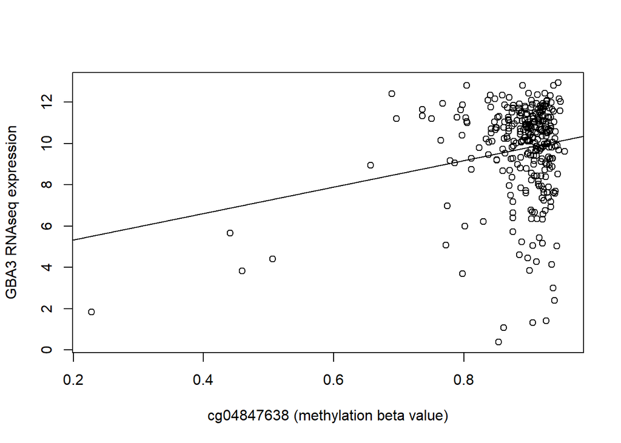

```r
# cg04847638
plot(
  meth.data2["cg04847638",],
  rna.data2["GBA3",],
  xlab="cg04847638 (methylation beta value)",
  ylab="GBA3 RNAseq expression"
)
abline(lm(rna.data2["GBA3",] ~ meth.data2["cg04847638",]))
```

```r
png("KIRC_GBA3_ExpVsMeth2.png")
plot(
  meth.data2["cg04847638",],
  rna.data2["GBA3",],
  xlab="cg04847638 (methylation beta value)",
  ylab="GBA3 RNAseq expression"
)
abline(lm(rna.data2["GBA3",] ~ meth.data2["cg04847638",]))
dev.off()
```

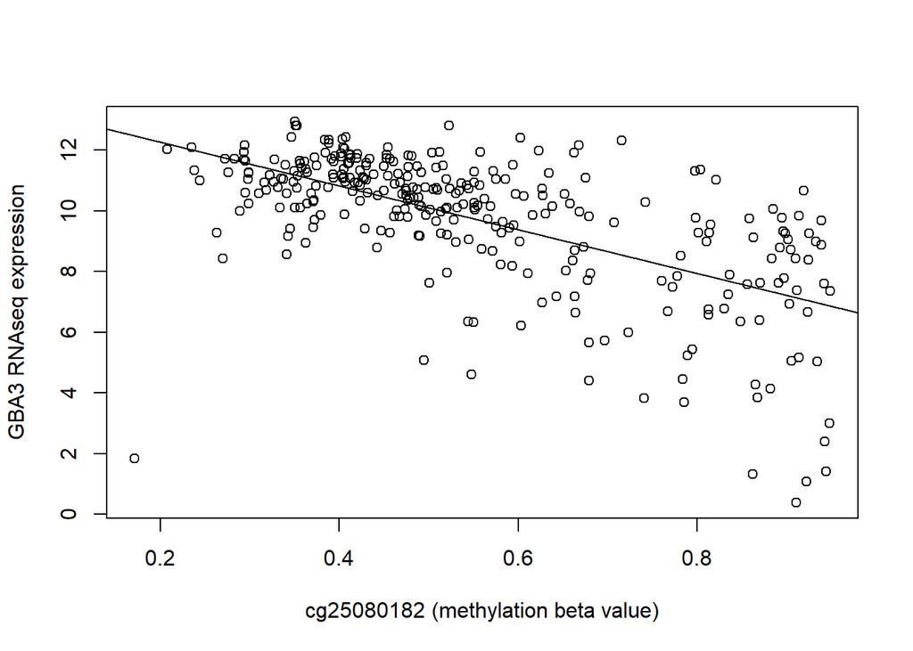

```r
# cg25080182
plot(
  meth.data2["cg25080182",],
  rna.data2["GBA3",],
  xlab="cg25080182 (methylation beta value)",
  ylab="GBA3 RNAseq expression"
)
abline(lm(rna.data2["GBA3",] ~ meth.data2["cg25080182",]))
```

```r
png("KIRC_GBA3_ExpVsMeth3.png")
plot(
  meth.data2["cg25080182",],
  rna.data2["GBA3",],
  xlab="cg25080182 (methylation beta value)",
  ylab="GBA3 RNAseq expression"
)
abline(lm(rna.data2["GBA3",] ~ meth.data2["cg25080182",]))
dev.off()
```

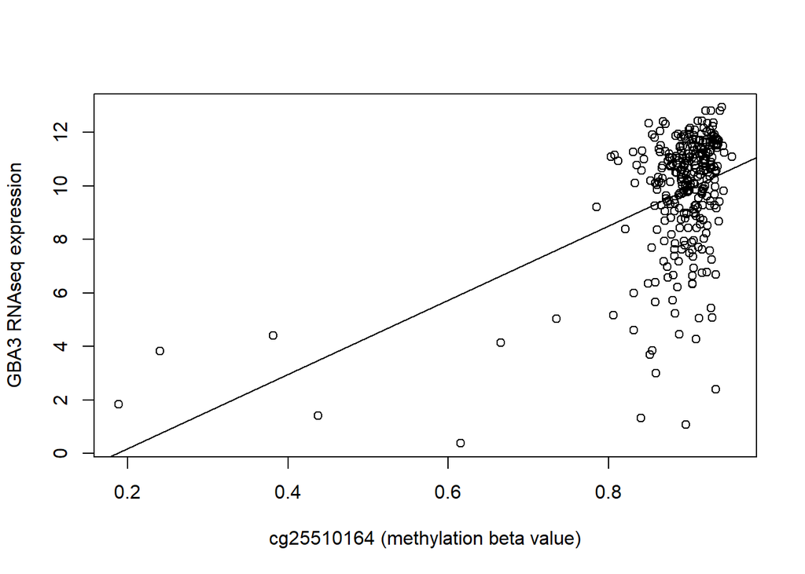

```r
# cg25510164
plot(
  meth.data2["cg25510164",],
  rna.data2["GBA3",],
  xlab="cg25510164 (methylation beta value)",
  ylab="GBA3 RNAseq expression"
)
abline(lm(rna.data2["GBA3",] ~ meth.data2["cg25510164",]))
```

```r
png("KIRC_GBA3_ExpVsMeth4.png")
plot(
  meth.data2["cg25510164",],
  rna.data2["GBA3",],
  xlab="cg25510164 (methylation beta value)",
  ylab="GBA3 RNAseq expression"
)
abline(lm(rna.data2["GBA3",] ~ meth.data2["cg25510164",]))
dev.off()
```

boxplot

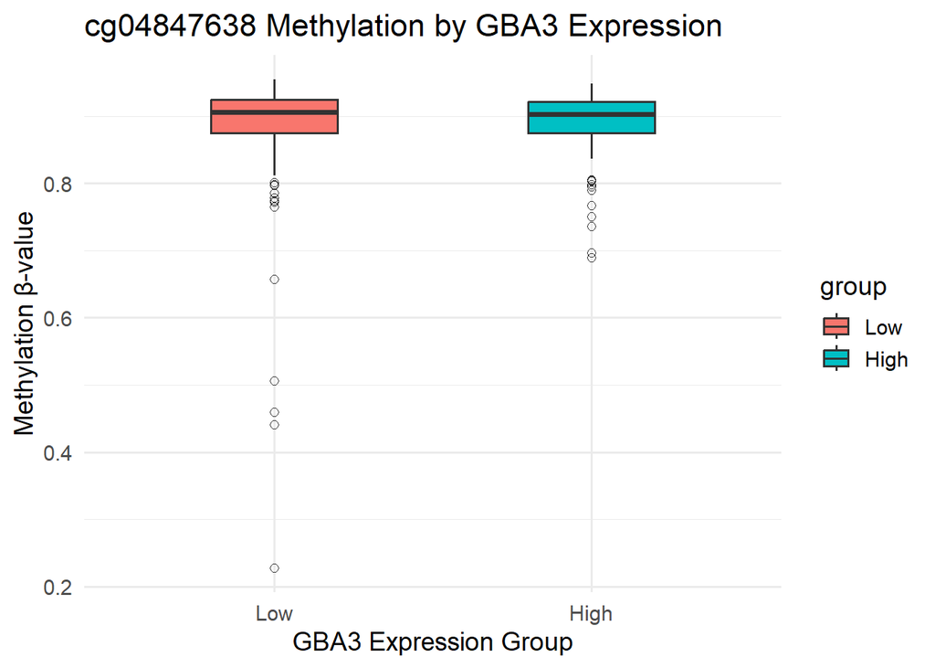

```r
library(ggplot2)
# cg04847638
beta  <- meth.data.GBA3["cg04847638", ]
group <- factor(GBA3.high2, labels = c("Low", "High"))

ggplot(data.frame(beta, group), aes(x = group, y = beta, fill = group)) +
  geom_boxplot(outlier.shape = 1, outlier.size = 2, width = 0.4) +
  labs(title = "cg04847638 Methylation by GBA3 Expression",
       x = "GBA3 Expression Group",
       y = "Methylation β-value") +
  theme_minimal(base_size = 14)
```

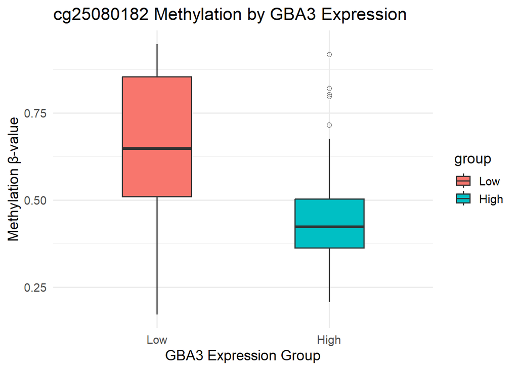

```r
# cg25080182
beta  <- meth.data.GBA3["cg25080182", ]
group <- factor(GBA3.high2, labels = c("Low", "High"))

ggplot(data.frame(beta, group), aes(x = group, y = beta, fill = group)) +
  geom_boxplot(outlier.shape = 1, outlier.size = 2, width = 0.4) +
  labs(title = "cg25080182 Methylation by GBA3 Expression",
       x = "GBA3 Expression Group",
       y = "Methylation β-value") +
  theme_minimal(base_size = 14)
```

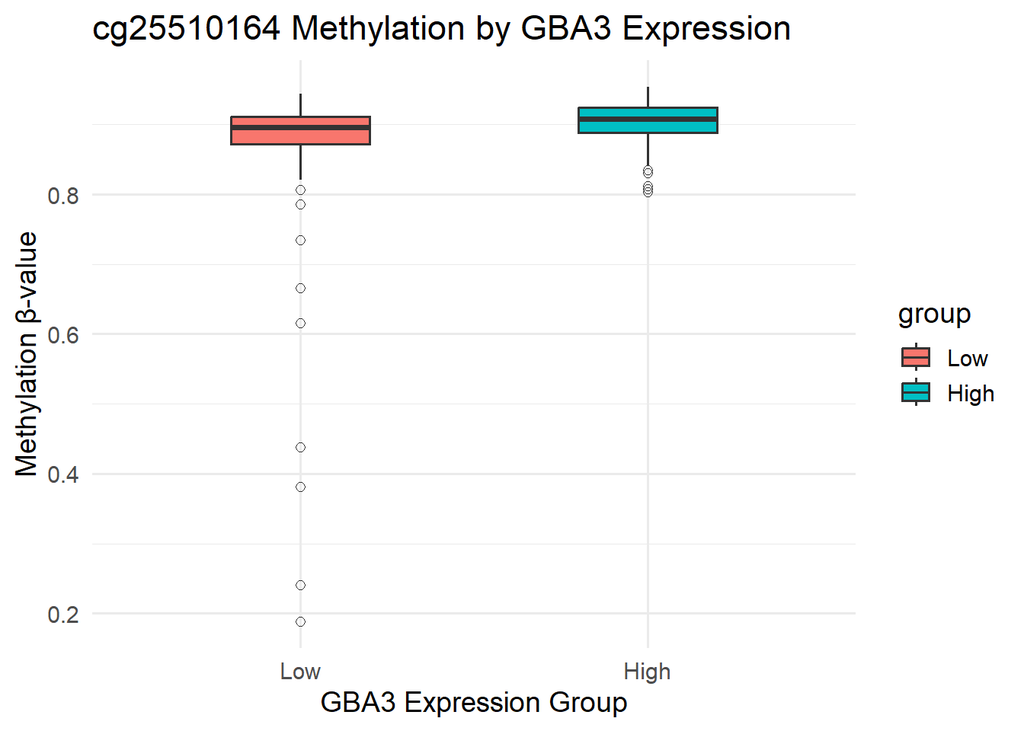

```r
# cg25510164
beta  <- meth.data.GBA3["cg25510164", ]
group <- factor(GBA3.high2, labels = c("Low", "High"))

ggplot(data.frame(beta, group), aes(x = group, y = beta, fill = group)) +
  geom_boxplot(outlier.shape = 1, outlier.size = 2, width = 0.4) +
  labs(title = "cg25510164 Methylation by GBA3 Expression",
       x = "GBA3 Expression Group",
       y = "Methylation β-value") +
  theme_minimal(base_size = 14)
```

Survival analysis by BGA3 methylation(cg25080182)

```r
# Create binary variable based on median methylation
GBA3.high3 <- as.numeric(meth.data.GBA3["cg25080182",] > median(meth.data.GBA3["cg25080182",]))
surv.data2$GBA3.high3 <- GBA3.high3

# Univariate Cox: test if high methylation (GBA3 silencing) predicts worse OS
cox_model_GBA3_meth <- coxph(Surv(OS.time, OS) ~ GBA3.high3, data = surv.data2)
summary(cox_model_GBA3_meth)
```

```
## Call:
## coxph(formula = Surv(OS.time, OS) ~ GBA3.high3, data = surv.data2)
##
##   n= 307, number of events= 112
##
##              coef exp(coef) se(coef)     z Pr(>|z|)
## GBA3.high3 0.9189    2.5066   0.2008 4.575 4.76e-06 ***
## ---
## Signif. codes:  0 '***' 0.001 '**' 0.01 '*' 0.05 '.' 0.1 ' ' 1
##
##            exp(coef) exp(-coef) lower .95 upper .95
## GBA3.high3     2.507     0.3989     1.691     3.716
##
## Concordance= 0.614  (se = 0.024 )
## Likelihood ratio test= 22.35  on 1 df,   p=2e-06
## Wald test            = 20.93  on 1 df,   p=5e-06
## Score (logrank) test = 22.39  on 1 df,   p=2e-06
```

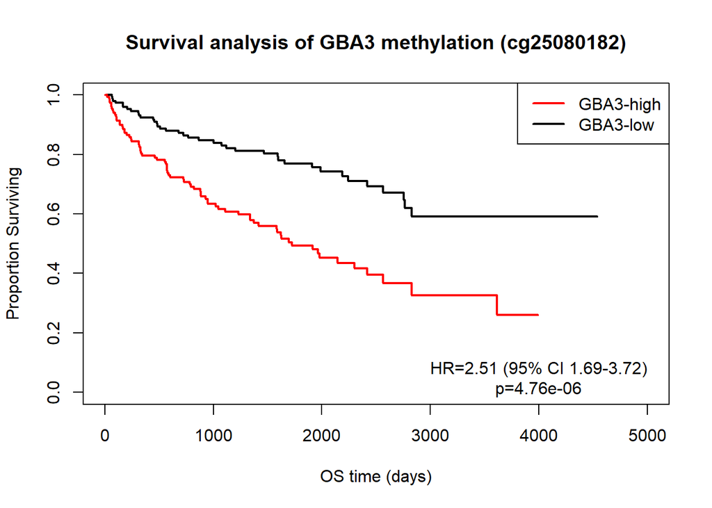

```r
# KM plot: visualize survival difference between high- and low-methylation groups
fit_meth <- survfit(Surv(OS.time, OS) ~ GBA3.high3, data = surv.data2)
plot(fit_meth,
     col = c("black", "red"),
     lwd = 2,
     xlab="OS time (days)",
     ylab="Proportion Surviving",
     main = "Survival analysis of GBA3 methylation (cg25080182)",
     xlim = c(0, 5000)
)
legend("topright", c("GBA3-high", "GBA3-low"), col=c("red", "black"), lwd=2)
text(4000, 0.05, "HR=2.51 (95% CI 1.69-3.72)
p=4.76e-06")
```

Multivariate Cox model: tests whether GBA3-methylation status remains significant after adjusting for GBA3 expression and significant clinical covariates

```r
# Add 4 new binary variables (0/1 variables) to convert "textual clinical information" into dummy variables for "high-risk"
library(dplyr)
```

```r
clin.data_01 <- clin.data %>%
  mutate(
    grade.high = ifelse(grepl("G3|G4", neoplasm_histologic_grade), 1, 0),
    stage.high = ifelse(grepl("Stage III|Stage IV", pathologic_stage), 1, 0),
    stage.T.high = ifelse(grepl("T3|T3a|T3b|T3c|T4", pathologic_T), 1, 0),
    stage.M.high = ifelse(grepl("M1", pathologic_M), 1, 0)
  )
# Append continuous GBA3 expression and binary clinical covariates to survival set
exp_meth <- as.numeric(rna.data["GBA3", rownames(surv.data2)])
surv.data2$exp_meth <- exp_meth
surv.data2$age <- as.numeric(clin.data[rownames(surv.data2), "age_at_initial_pathologic_diagnosis"])
surv.data2$grade <- as.numeric(clin.data_01[rownames(surv.data2), "grade.high"])
surv.data2$stage <- as.numeric(clin.data_01[rownames(surv.data2), "stage.high"])
surv.data2$stage_T <- as.numeric(clin.data_01[rownames(surv.data2), "stage.T.high"])
surv.data2$stage_M <- as.numeric(clin.data_01[rownames(surv.data2), "stage.M.high"])

# Multivariate Cox
cox_model_meth <- coxph(Surv(OS.time, OS) ~ GBA3.high3 + exp_meth + age + grade + stage + stage_T +stage_M,
                   data = surv.data2)
summary(cox_model_meth)
```

```
## Call:
## coxph(formula = Surv(OS.time, OS) ~ GBA3.high3 + exp_meth + age +
##     grade + stage + stage_T + stage_M, data = surv.data2)
##
##   n= 307, number of events= 112
##
##                 coef exp(coef)  se(coef)      z Pr(>|z|)
## GBA3.high3  0.352036  1.421960  0.237762  1.481   0.1387
## exp_meth   -0.209135  0.811286  0.044932 -4.654 3.25e-06 ***
## age         0.044823  1.045842  0.009416  4.760 1.93e-06 ***
## grade       0.286589  1.331877  0.241043  1.189   0.2345
## stage       0.825896  2.283927  0.423698  1.949   0.0513 .
## stage_T    -0.237627  0.788497  0.335977 -0.707   0.4794
## stage_M     1.161062  3.193324  0.245097  4.737 2.17e-06 ***
## ---
## Signif. codes:  0 '***' 0.001 '**' 0.01 '*' 0.05 '.' 0.1 ' ' 1
##
##            exp(coef) exp(-coef) lower .95 upper .95
## GBA3.high3    1.4220     0.7033    0.8923     2.266
## exp_meth      0.8113     1.2326    0.7429     0.886
## age           1.0458     0.9562    1.0267     1.065
## grade         1.3319     0.7508    0.8304     2.136
## stage         2.2839     0.4378    0.9955     5.240
## stage_T       0.7885     1.2682    0.4081     1.523
## stage_M       3.1933     0.3132    1.9752     5.163
##
## Concordance= 0.791  (se = 0.021 )
## Likelihood ratio test= 127.2  on 7 df,   p=<2e-16
## Wald test            = 124.3  on 7 df,   p=<2e-16
## Score (logrank) test = 148.5  on 7 df,   p=<2e-16
```

Cox regression mediation analysis

```r
library(mediation)
library(mets)
GBA3_meth <- as.numeric(meth.data.GBA3["cg25080182", rownames(surv.data2)])
surv.data2$GBA3_meth <- GBA3_meth

# mediator model
med.fit  <- lm(exp_meth ~ GBA3_meth, data = surv.data2)

# Survival Model
out.fit <- survreg(Surv(OS.time, OS) ~ GBA3_meth + exp_meth, data = surv.data2)

# mediation analysis
med.out <- mediate(med.fit, out.fit,
                   treat   = "GBA3_meth",
                   mediator= "exp_meth",
                   sims    = 500,
                   boot    = TRUE,
                   outcome = "OS.time")
```

```
## Running nonparametric bootstrap
```

```r
summary(med.out)
```

```
##
## Causal Mediation Analysis
##
## Nonparametric Bootstrap Confidence Intervals with the Percentile Method
##
##                             Estimate 95% CI Lower 95% CI Upper p-value
## ACME (control)           -1.3074e+04  -2.9749e+04  -5.1328e+03  <2e-16 ***
## ACME (treated)           -6.9189e+03  -2.5007e+04  -1.7475e+03  <2e-16 ***
## ADE (control)            -7.8078e+03  -3.0445e+04   9.3863e+03   0.252
## ADE (treated)            -1.6527e+03  -8.3546e+03   8.6545e+02   0.252
## Total Effect             -1.4727e+04  -3.4684e+04  -7.0133e+03  <2e-16 ***
## Prop. Mediated (control)  8.8777e-01   5.8144e-01   1.0854e+00  <2e-16 ***
## Prop. Mediated (treated)  4.6982e-01   9.0481e-02   1.7242e+00  <2e-16 ***
## ACME (average)           -9.9965e+03  -2.5150e+04  -3.8220e+03  <2e-16 ***
## ADE (average)            -4.7303e+03  -1.9459e+04   5.2713e+03   0.252
## Prop. Mediated (average)  6.7880e-01   3.5412e-01   1.4258e+00  <2e-16 ***
## ---
## Signif. codes:  0 '***' 0.001 '**' 0.01 '*' 0.05 '.' 0.1 ' ' 1
##
## Sample Size Used: 307
##
##
## Simulations: 500
```

Let’s explore GBA3 expression differences explained by CNV

```r
knitr::opts_chunk$set(echo = TRUE, message = FALSE, warning = FALSE)
library(data.table)
library(dplyr)
library(ggplot2)
library(pheatmap)
library(survival)
library(UCSCXenaTools)
```

Download KIRC Copy Number Matrix (GISTIC2 Discrete Values)

```r
cnv_dl <- downloadTCGA(
  project   = "KIRC",
  data_type = "Gene Level Copy Number",
  file_type = "Gistic2 thresholded",
  destdir   = "data",
  force     = FALSE
)

cnv_file <- cnv_dl$destfiles[1]
cnv_raw <- fread(cnv_file)
genes <- cnv_raw[[1]]
cnv <- cnv_raw[, -1]
cnv <- as.data.frame(cnv)
rownames(cnv) <- genes
```

Check the “missingness” per sample

```r
missing_per_sample <- colMeans(is.na(cnv))
summary(missing_per_sample)
```

```
##    Min. 1st Qu.  Median    Mean 3rd Qu.    Max.
##       0       0       0       0       0       0
```

Distribution of genomic instability in KIRC

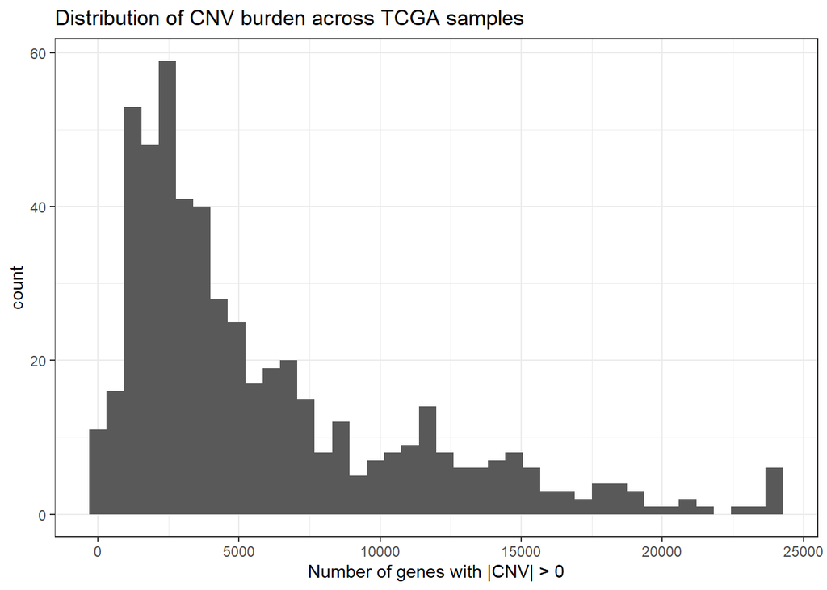

```r
# Define CNV burden as the number of genes in a sample with non-zero CNV value
cnv_burden <- apply(cnv != 0, 2, sum)
df_burden <- data.frame(Sample = names(cnv_burden), CNV_burden = cnv_burden)
ggplot(df_burden, aes(x = CNV_burden)) +
  geom_histogram(bins = 40) +
  theme_bw() +
  xlab("Number of genes with |CNV| > 0") +
  ggtitle("Distribution of CNV burden across TCGA samples")
```

High-frequency variant gene

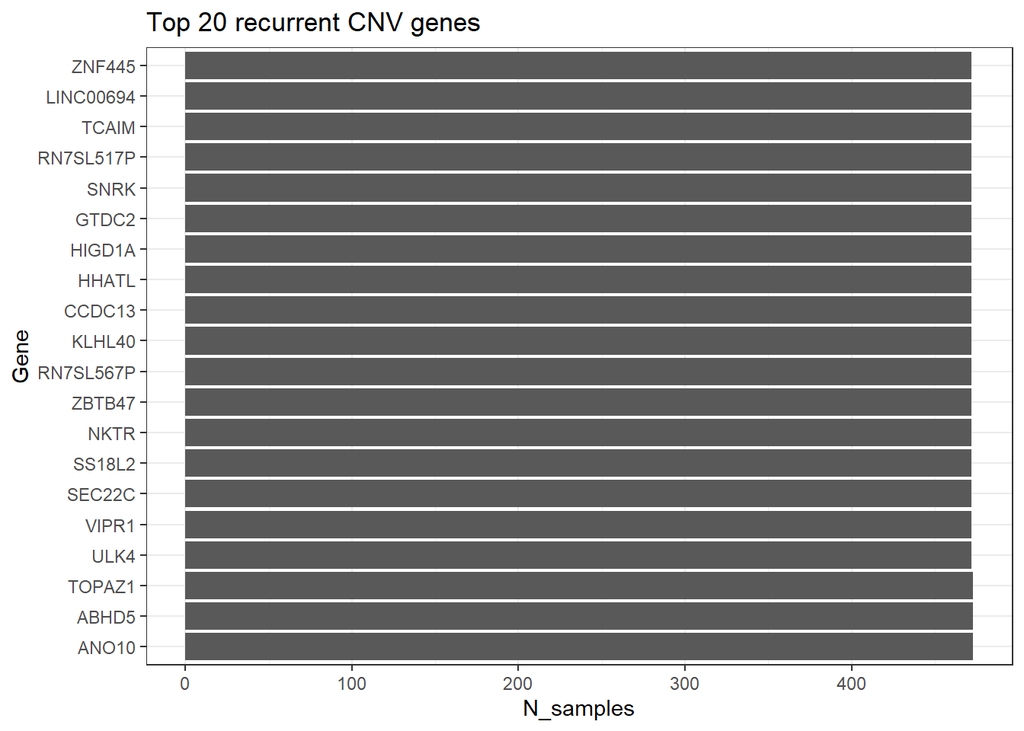

```r
# For each gene, how many samples it is altered in (CNV is nonzero)
recurrent_counts <- rowSums(cnv != 0)
top_genes <- sort(recurrent_counts, decreasing = TRUE)[1:20]

# Barplot of top recurrent genes
df_top <- data.frame(Gene = factor(names(top_genes), levels = names(top_genes)),
                     N_samples = as.numeric(top_genes))

ggplot(df_top, aes(x = Gene, y = N_samples)) +
  geom_bar(stat = "identity") +
  coord_flip() +
  theme_bw() +
  ggtitle("Top 20 recurrent CNV genes")
```

Check if GBA3 CNV data exist

```r
if ("GBA3" %in% rownames(cnv)) {
  GBA3_vals <- as.numeric(cnv["GBA3", ])
  table(GBA3_vals)
} else {
  stop("GBA3 is not in the CNV matrix, please check the gene name or probe annotation
")
}
```

```
## GBA3_vals
##  -2  -1   0   1
##   1  69 443  15
```

```r
GBA3_cnv <- t(cnv["GBA3", ])
head(GBA3_cnv)
```

```
##                 GBA3
## TCGA-3Z-A93Z-01    0
## TCGA-6D-AA2E-01    0
## TCGA-A3-3306-01    0
## TCGA-A3-3307-01    0
## TCGA-A3-3308-01    0
## TCGA-A3-3311-01    0
```

```r
cnv_samples <- colnames(cnv)
cnv_samples <-gsub("\\.", "-", cnv_samples)
rownames(complete.surv.data) <- gsub("_", ".", rownames(complete.surv.data))

# Keep only samples present in both datasets, preserving identical order
keep_rows <- rownames(complete.surv.data) %in% cnv_samples
surv_sub <- complete.surv.data[keep_rows, , drop = FALSE]
common_id <- intersect(cnv_samples, rownames(complete.surv.data))
cnv_samples <- cnv_samples[cnv_samples %in% common_id]
surv_sub <- complete.surv.data[match(common_id, rownames(complete.surv.data)), , drop = FALSE]

# Quick sanity check of matched IDs
head(cbind(cnv = cnv_samples[1:10],
           surv = rownames(surv_sub)[1:10]))
```

```
##      cnv               surv
## [1,] "TCGA-3Z-A93Z-01" "TCGA-3Z-A93Z-01"
## [2,] "TCGA-A3-3306-01" "TCGA-A3-3306-01"
## [3,] "TCGA-A3-3307-01" "TCGA-A3-3307-01"
## [4,] "TCGA-A3-3308-01" "TCGA-A3-3308-01"
## [5,] "TCGA-A3-3311-01" "TCGA-A3-3311-01"
## [6,] "TCGA-A3-3313-01" "TCGA-A3-3313-01"
```

```r
# Ensure GBA3 CNV data exist
if (!"GBA3" %in% rownames(cnv)) stop("GBA3 not found in dataset")

colnames(cnv) <- gsub("\\.", "-", colnames(cnv))
GBA3_vals <- as.numeric(cnv["GBA3", rownames(surv_sub)])

# Create binary CNV indicator: Deleted (≤ –1) vs. Notdeleted (0,1)
GBA3_status <- ifelse(GBA3_vals <= -1, "Deleted", "Notdeleted") |>
                factor(levels = c("Deleted", "Notdeleted"))

# Append categorical and dummy variables to survival table
surv_sub$GBA3_status <- GBA3_status
surv_sub$GBA3_CNV_deleted <- ifelse(GBA3_status == "Deleted", 1, 0)

table(surv_sub$GBA3_status)
```

```
##
##    Deleted Notdeleted
##         68        417
```

Gene expression by CNV grouping for GBA3

```r
# Extract GBA3 RNA-seq values (in the same order as surv-sub)
exp_vals <- as.numeric(rna.data["GBA3", rownames(surv_sub)])
exp_vals_data <- rna.data[, rownames(surv_sub)]


head(cbind(exp = colnames(exp_vals_data)[1:10],
           surv = rownames(surv_sub)[1:10]))
```

```
##      exp               surv
## [1,] "TCGA-3Z-A93Z-01" "TCGA-3Z-A93Z-01"
## [2,] "TCGA-A3-3306-01" "TCGA-A3-3306-01"
## [3,] "TCGA-A3-3307-01" "TCGA-A3-3307-01"
## [4,] "TCGA-A3-3308-01" "TCGA-A3-3308-01"
## [5,] "TCGA-A3-3311-01" "TCGA-A3-3311-01"
## [6,] "TCGA-A3-3313-01" "TCGA-A3-3313-01"
```

```r
# Pearson correlation: continuous expression vs. binary CNV status
cnv_binary <- surv_sub$GBA3_CNV_deleted
exp.CNV <- cor.test(exp_vals, cnv_binary, method = "pearson")
exp.CNV
```

```
##
##  Pearson's product-moment correlation
##
## data:  exp_vals and cnv_binary
## t = -3.6713, df = 483, p-value = 0.0002682
## alternative hypothesis: true correlation is not equal to 0
## 95 percent confidence interval:
##  -0.25013660 -0.07685882
## sample estimates:
##        cor
## -0.1647688
```

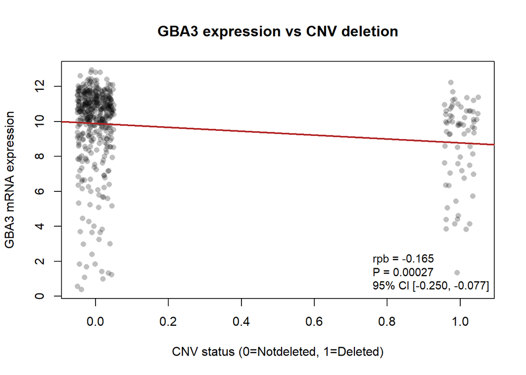

```r
plot(jitter(cnv_binary, amount = 0.05), exp_vals,
     xlab = "CNV status (0=Notdeleted, 1=Deleted)",
     ylab = "GBA3 mRNA expression",
     pch  = 16, col = "#00000040",
     main = "GBA3 expression vs CNV deletion")
abline(lm(exp_vals ~ cnv_binary), col = "firebrick", lwd = 2)
legend("bottomright", bty = "n",
       legend = c(
         sprintf("rpb = %.3f",  exp.CNV$estimate),
         sprintf("P = %.2g",    exp.CNV$p.value),
         sprintf("95%% CI [%.3f, %.3f]", exp.CNV$conf.int[1], exp.CNV$conf.int[2])
       ),
       text.col = "black", cex = 0.9)
```

Boxplot & Wilcoxon test

```r
# Median difference in gene expression between the deleted and notdeleted groups
med_exp_CNV <- tapply(exp_vals, GBA3_status, median, na.rm = TRUE)
med_exp_CNV
```

```
##    Deleted Notdeleted
##    9.78435   10.60080
```

```r
delta_exp_CNV <- med_exp_CNV["Deleted"] - med_exp_CNV["Notdeleted"]
delta_exp_CNV
```

```
##  Deleted
## -0.81645
```

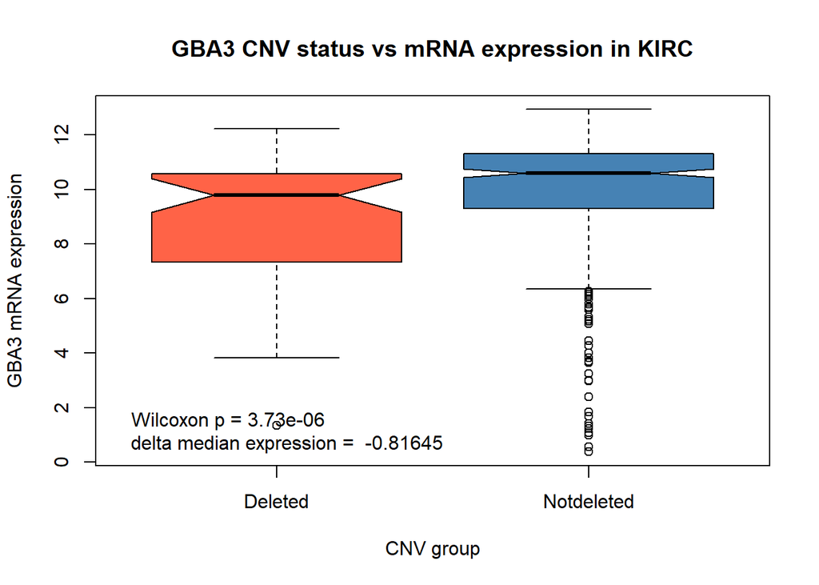

```r
# Basic box diagram
boxplot(exp_vals ~ GBA3_status,
        col    = c("tomato", "steelblue"),
        ylab   = "GBA3 mRNA expression",
        xlab   = "CNV group",
        main   = "GBA3 CNV status vs mRNA expression in KIRC",
        notch  = TRUE)
# Wilcoxon rank-sum test
w <- wilcox.test(exp_vals ~ GBA3_status, exact = FALSE)
legend("bottomleft", bty = "n",
       legend = c(
         paste("Wilcoxon p =", signif(w$p.value, 3)),
         paste("delta median expression = ", signif(delta_exp_CNV))
         ))
```

```r
png("GBA3_CNV_vs_Expr_base.png", width = 700, height = 500, res = 120)
boxplot(exp_vals ~ GBA3_status,
        col    = c("tomato", "steelblue"),
        ylab   = "GBA3 mRNA expression",
        xlab   = "CNV group",
        main   = "GBA3 CNV status vs mRNA expression in KIRC",
        notch  = TRUE)
# Wilcoxon rank-sum test
w <- wilcox.test(exp_vals ~ GBA3_status, exact = FALSE)
legend("bottomleft", bty = "n",
       legend = c(
         paste("Wilcoxon p =", signif(w$p.value, 3)),
         paste("delta median expression = ", signif(delta_exp_CNV))
         ))
dev.off()
```

Boxplot & Wilcoxon test confirm CNV-deleted tumors have significantly lower GBA3 mRNA (Δmedian = ‑0.8, p < 0.001).

Survival analysis by GBA3 CNV (Deleted vs Notdeleted)

```r
surv_sub$GBA3_status <- GBA3_status

# Univariate Cox: does GBA3 CNV deletion predict poorer OS?
cox_model_GBA3_status <- coxph(Surv(OS.time, OS) ~ GBA3_CNV_deleted, data = surv_sub)
summary(cox_model_GBA3_status)
```

```
## Call:
## coxph(formula = Surv(OS.time, OS) ~ GBA3_CNV_deleted, data = surv_sub)
##
##   n= 485, number of events= 168
##
##                    coef exp(coef) se(coef)     z Pr(>|z|)
## GBA3_CNV_deleted 0.7246    2.0639   0.1865 3.885 0.000102 ***
## ---
## Signif. codes:  0 '***' 0.001 '**' 0.01 '*' 0.05 '.' 0.1 ' ' 1
##
##                  exp(coef) exp(-coef) lower .95 upper .95
## GBA3_CNV_deleted     2.064     0.4845     1.432     2.975
##
## Concordance= 0.55  (se = 0.016 )
## Likelihood ratio test= 13.09  on 1 df,   p=3e-04
## Wald test            = 15.09  on 1 df,   p=1e-04
## Score (logrank) test = 15.76  on 1 df,   p=7e-05
```

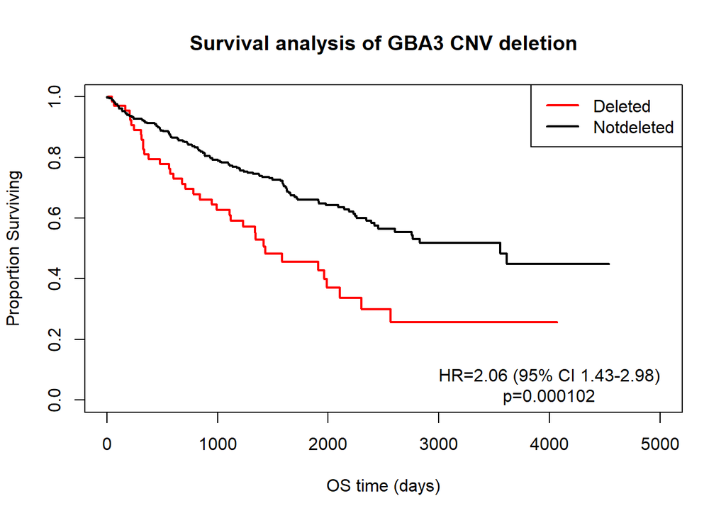

```r
# KM curve comparing Deleted vs Not-deleted
fit <- survfit(Surv(OS.time, OS) ~ GBA3_status, data = surv_sub)
plot(fit,
     col = c("red", "black"),
     lwd = 2,
     xlab="OS time (days)",
     ylab="Proportion Surviving",
     main = "Survival analysis of GBA3 CNV deletion",
     xlim = c(0, 5000)
)
legend("topright", c("Deleted", "Notdeleted"), col=c("red", "black"), lwd=2)
text(4000, 0.05, "HR=2.06 (95% CI 1.43-2.98)
p=0.000102")
```

Multivariate Cox model: tests whether CNV deletion remains significant after adjusting for GBA3 expression and significant clinical covariates

```r
# Add 4 new binary variables (0/1 variables) to convert "textual clinical information" into dummy variables for "high-risk"
library(dplyr)

clin.data_01 <- clin.data %>%
  mutate(
    grade.high = ifelse(grepl("G3|G4", neoplasm_histologic_grade), 1, 0),
    stage.high = ifelse(grepl("Stage III|Stage IV", pathologic_stage), 1, 0),
    stage.T.high = ifelse(grepl("T3|T3a|T3b|T3c|T4", pathologic_T), 1, 0),
    stage.M.high = ifelse(grepl("M1", pathologic_M), 1, 0)
  )

surv_sub$GBA3_CNV_deleted <- ifelse(GBA3_status == "Deleted", 1, 0)
surv_sub$exp_vals <- exp_vals
surv_sub$age <- as.numeric(clin.data[rownames(surv_sub), "age_at_initial_pathologic_diagnosis"])
surv_sub$grade <- as.numeric(clin.data_01[rownames(surv_sub), "grade.high"])
surv_sub$stage <- as.numeric(clin.data_01[rownames(surv_sub), "stage.high"])
surv_sub$stage_T <- as.numeric(clin.data_01[rownames(surv_sub), "stage.T.high"])
surv_sub$stage_M <- as.numeric(clin.data_01[rownames(surv_sub), "stage.M.high"])

cox_model <- coxph(Surv(OS.time, OS) ~ GBA3_CNV_deleted + exp_vals + age + grade + stage + stage_T +stage_M,
                   data = surv_sub)
summary(cox_model)
```

```
## Call:
## coxph(formula = Surv(OS.time, OS) ~ GBA3_CNV_deleted + exp_vals +
##     age + grade + stage + stage_T + stage_M, data = surv_sub)
##
##   n= 485, number of events= 168
##
##                       coef exp(coef)  se(coef)      z Pr(>|z|)
## GBA3_CNV_deleted  0.288009  1.333770  0.189085  1.523   0.1277
## exp_vals         -0.198149  0.820248  0.028683 -6.908 4.91e-12 ***
## age               0.037099  1.037795  0.007068  5.249 1.53e-07 ***
## grade             0.344457  1.411223  0.188808  1.824   0.0681 .
## stage             0.885610  2.424464  0.362344  2.444   0.0145 *
## stage_T          -0.320989  0.725431  0.319246 -1.005   0.3147
## stage_M           0.972897  2.645597  0.198052  4.912 9.00e-07 ***
## ---
## Signif. codes:  0 '***' 0.001 '**' 0.01 '*' 0.05 '.' 0.1 ' ' 1
##
##                  exp(coef) exp(-coef) lower .95 upper .95
## GBA3_CNV_deleted    1.3338     0.7498    0.9207    1.9321
## exp_vals            0.8202     1.2191    0.7754    0.8677
## age                 1.0378     0.9636    1.0235    1.0523
## grade               1.4112     0.7086    0.9747    2.0432
## stage               2.4245     0.4125    1.1918    4.9322
## stage_T             0.7254     1.3785    0.3880    1.3562
## stage_M             2.6456     0.3780    1.7945    3.9004
##
## Concordance= 0.781  (se = 0.018 )
## Likelihood ratio test= 160.1  on 7 df,   p=<2e-16
## Wald test            = 161.7  on 7 df,   p=<2e-16
## Score (logrank) test = 190.1  on 7 df,   p=<2e-16
```

Causal mediation analysis to quantify the effect of GBA3 deletion on survival via the pathway: GBA3 deletion → decreased GBA3 expression → adverse prognostic impact.

```r
# mediator model
med.fit1 <- glm(exp_vals ~ GBA3_CNV_deleted, data = surv_sub)

# Survival Model
out.fit1 <- survreg(Surv(OS.time, OS) ~ GBA3_CNV_deleted + exp_vals, data = surv_sub)

# mediation analysis
med.out1 <- mediate(med.fit1, out.fit1,
                   treat   = "GBA3_CNV_deleted",
                   mediator= "exp_vals",
                   sims    = 500,
                   boot    = TRUE,
                   outcome = "OS.time")

summary(med.out1)
```

```
##
## Causal Mediation Analysis
##
## Nonparametric Bootstrap Confidence Intervals with the Percentile Method
##
##                             Estimate 95% CI Lower 95% CI Upper p-value
## ACME (control)           -9.3265e+02  -1.7391e+03  -4.3606e+02  <2e-16 ***
## ACME (treated)           -5.4910e+02  -1.1283e+03  -2.1789e+02  <2e-16 ***
## ADE (control)            -2.0926e+03  -3.6752e+03  -6.2521e+02   0.004 **
## ADE (treated)            -1.7091e+03  -3.0199e+03  -4.9724e+02   0.004 **
## Total Effect             -2.6417e+03  -4.2740e+03  -1.3577e+03  <2e-16 ***
## Prop. Mediated (control)  3.5305e-01   1.7045e-01   6.9816e-01  <2e-16 ***
## Prop. Mediated (treated)  2.0786e-01   7.6995e-02   6.0928e-01  <2e-16 ***
## ACME (average)           -7.4087e+02  -1.3998e+03  -3.3153e+02  <2e-16 ***
## ADE (average)            -1.9008e+03  -3.3242e+03  -5.6790e+02   0.004 **
## Prop. Mediated (average)  2.8045e-01   1.2408e-01   6.5660e-01  <2e-16 ***
## ---
## Signif. codes:  0 '***' 0.001 '**' 0.01 '*' 0.05 '.' 0.1 ' ' 1
##
## Sample Size Used: 485
##
##
## Simulations: 500
```